# 431 Class 16

Thomas E. Love, Ph.D.

2024-10-17

## Today’s Agenda

- Discussion of Quiz 1
- Dealing with Missing Data
- Simple (Single) Imputation using the `mice` package
- Multiple Imputation using the `mice` package

(MICE = Multiple Imputation through Chained Equations)

- Breakout Activity 3 Results

## Today’s Packages

```r
library(janitor)
library(googlesheets4)
library(knitr)
library(kableExtra)
library(mice)
library(naniar)
library(xfun)
library(easystats)
library(tidyverse)

theme_set(theme_light())

source("c16/data/Love-431.R")
```

## 700 Veterans with HBP

700 male veterans with a hypertension diagnosis.

- Pulse Pressure = Systolic BP - Diastolic BP.

```r
hbp700 <- read_csv("c16/data/hbp700.csv", show_col_types = FALSE) |>
  janitor::clean_names() |>
  mutate(across(where(is.character), as_factor)) |>
  mutate(pp = sbp - dbp) |>
  mutate(subject = as.character(subject))

dim(hbp700)
```

```
[1] 700  10
```

```r
hbp700 |> head(4)
```

```
# A tibble: 4 × 10
  subject   age race    nincome   bmi tobacco   ldl   sbp   dbp    pp
  <chr>   <dbl> <fct>     <dbl> <dbl> <fct>   <dbl> <dbl> <dbl> <dbl>
1 hbp001     65 NHBlack   27900  23.4 Never     104   150    87    63
2 hbp002     64 NHWhite      NA  35.5 Former     79   119    77    42
3 hbp003     62 NHBlack   71600  NA   Former     77   118    80    38
4 hbp004     82 <NA>      37300  24.5 Former     63   113    52    61
```

## Missingness in `hbp700`

```r
miss_var_summary(hbp700)
```

```
# A tibble: 10 × 3
   variable n_miss pct_miss
   <chr>     <int>    <num>
 1 race        112   16
 2 tobacco     110   15.7
 3 bmi          19    2.71
 4 nincome      11    1.57
 5 ldl           7    1
 6 sbp           1    0.143
 7 dbp           1    0.143
 8 pp            1    0.143
 9 subject       0    0
10 age           0    0
```

```r
miss_case_table(hbp700)
```

```
# A tibble: 4 × 3
  n_miss_in_case n_cases pct_cases
           <int>   <int>     <dbl>
1              0     461    65.9
2              1     219    31.3
3              2      17     2.43
4              3       3     0.429
```

## Categorical Variables in `hbp700`

```r
hbp700 |> tabyl(race, tobacco) |>
  adorn_totals(where = c("row", "col"))
```

```
    race Never Former Current NA_ Total
 NHBlack    81    260       4  80   425
 NHWhite    31    109       2  21   163
    <NA>    17     86       0   9   112
   Total   129    455       6 110   700
```

```r
hbp700 |> tabyl(race) |> adorn_pct_formatting()
```

```
    race   n percent valid_percent
 NHBlack 425   60.7%         72.3%
 NHWhite 163   23.3%         27.7%
    <NA> 112   16.0%             -
```

```r
hbp700 |> tabyl(tobacco) |> adorn_pct_formatting()
```

```
 tobacco   n percent valid_percent
   Never 129   18.4%         21.9%
  Former 455   65.0%         77.1%
 Current   6    0.9%          1.0%
    <NA> 110   15.7%             -
```

## Quantitative Variables in `hbp700`

```r
s_1 <- hbp700 |> reframe(lovedist(age)) |> mutate(var = "age")
s_2 <- hbp700 |> reframe(lovedist(nincome)) |> mutate(var = "nincome")
s_3 <- hbp700 |> reframe(lovedist(bmi)) |> mutate(var = "bmi")
s_4 <- hbp700 |> reframe(lovedist(ldl)) |> mutate(var = "ldl")
s_5 <- hbp700 |> reframe(lovedist(sbp)) |> mutate(var = "sbp")
s_6 <- hbp700 |> reframe(lovedist(dbp)) |> mutate(var = "dbp")
s_7 <- hbp700 |> reframe(lovedist(pp)) |> mutate(var = "pp")

rbind(s_1, s_2, s_3, s_4, s_5, s_6, s_7) |>
  relocate(var) |> kable(digits = 1) |>
  kable_styling(full_width = F, font_size = 20)
```

| var | n | miss | mean | sd | med | mad | min | q25 | q75 | max |
| --- | --- | --- | --- | --- | --- | --- | --- | --- | --- | --- |
| age | 700 | 0 | 65.6 | 9.4 | 65.0 | 8.9 | 38.0 | 59.0 | 71.0 | 90.0 |
| nincome | 700 | 11 | 43820.6 | 17621.0 | 41800.0 | 16456.9 | 16800.0 | 28600.0 | 51700.0 | 105400.0 |
| bmi | 700 | 19 | 31.1 | 6.5 | 30.4 | 5.9 | 16.8 | 26.6 | 34.8 | 62.6 |
| ldl | 700 | 7 | 82.7 | 27.8 | 80.0 | 23.7 | 40.0 | 63.0 | 96.0 | 225.0 |
| sbp | 700 | 1 | 133.4 | 17.8 | 132.0 | 17.8 | 88.0 | 121.0 | 144.5 | 212.0 |
| dbp | 700 | 1 | 76.4 | 10.1 | 76.0 | 8.9 | 49.0 | 70.0 | 82.0 | 122.0 |
| pp | 700 | 1 | 57.0 | 14.1 | 56.0 | 13.3 | 22.0 | 47.0 | 66.0 | 111.0 |

## Today’s Outcome: Pulse Pressure

- Pulse Pressure = Systolic BP - Diastolic BP.

```r
hbp700 <- hbp700 |> mutate(pp = sbp - dbp)

ggplot(hbp700, aes(x = pp, y = "pp")) + geom_violin() +
  geom_boxplot(width = 0.3) + labs(x = "Pulse Pressure (SBP - DBP)", y = "") +
  stat_summary(fun = "mean", geom = "point", col = "red", size = 2)
```

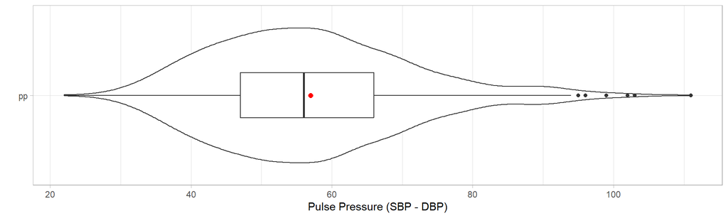

## Using `race` to predict `sbp` - `dbp`

- 700 subjects: 1 missing `sbp` & `dbp` plus 112 missing `race`.

```r
fit1 <- lm((sbp-dbp) ~ race, data = hbp700)
summary(fit1)
```

```
Call:
lm(formula = (sbp - dbp) ~ race, data = hbp700)

Residuals:
    Min      1Q  Median      3Q     Max
-28.191 -10.611  -1.611   8.809  53.809

Coefficients:
            Estimate Std. Error t value Pr(>|t|)
(Intercept)  57.1906     0.6882  83.104   <2e-16 ***
raceNHWhite  -1.5795     1.3100  -1.206    0.228
---
Signif. codes:  0 '***' 0.001 '**' 0.01 '*' 0.05 '.' 0.1 ' ' 1

Residual standard error: 14.19 on 585 degrees of freedom
  (113 observations deleted due to missingness)
Multiple R-squared:  0.002479,  Adjusted R-squared:  0.0007737
F-statistic: 1.454 on 1 and 585 DF,  p-value: 0.2284
```

## Assessing `fit1`

```r
n_obs(fit1)
```

```
[1] 587
```

```r
model_parameters(fit1)
```

```
Parameter      | Coefficient |   SE |         95% CI | t(585) |      p
----------------------------------------------------------------------
(Intercept)    |       57.19 | 0.69 | [55.84, 58.54] |  83.10 | < .001
race [NHWhite] |       -1.58 | 1.31 | [-4.15,  0.99] |  -1.21 | 0.228
```

```r
model_performance(fit1)
```

```
# Indices of model performance

AIC      |     AICc |      BIC |    R2 | R2 (adj.) |   RMSE |  Sigma
--------------------------------------------------------------------
4783.684 | 4783.725 | 4796.809 | 0.002 | 7.737e-04 | 14.163 | 14.187
```

## Add in age, as a covariate

```r
fit2 <- lm((sbp-dbp) ~ race + age, data = hbp700)
summary(fit2)
```

```
Call:
lm(formula = (sbp - dbp) ~ race + age, data = hbp700)

Residuals:
    Min      1Q  Median      3Q     Max
-29.297 -10.062  -1.709   7.953  53.321

Coefficients:
            Estimate Std. Error t value Pr(>|t|)
(Intercept) 36.32490    4.09642   8.867  < 2e-16 ***
raceNHWhite -2.03827    1.28523  -1.586    0.113
age          0.32355    0.06266   5.164 3.32e-07 ***
---
Signif. codes:  0 '***' 0.001 '**' 0.01 '*' 0.05 '.' 0.1 ' ' 1

Residual standard error: 13.89 on 584 degrees of freedom
  (113 observations deleted due to missingness)
Multiple R-squared:  0.04604,   Adjusted R-squared:  0.04277
F-statistic: 14.09 on 2 and 584 DF,  p-value: 1.055e-06
```

## Assessing `fit2`

```r
n_obs(fit2) # any more missingness?
```

```
[1] 587
```

```r
model_parameters(fit2)
```

```
Parameter      | Coefficient |   SE |         95% CI | t(584) |      p
----------------------------------------------------------------------
(Intercept)    |       36.32 | 4.10 | [28.28, 44.37] |   8.87 | < .001
race [NHWhite] |       -2.04 | 1.29 | [-4.56,  0.49] |  -1.59 | 0.113
age            |        0.32 | 0.06 | [ 0.20,  0.45] |   5.16 | < .001
```

```r
model_performance(fit2)
```

```
# Indices of model performance

AIC      |     AICc |      BIC |    R2 | R2 (adj.) |   RMSE |  Sigma
--------------------------------------------------------------------
4759.475 | 4759.543 | 4776.975 | 0.046 |     0.043 | 13.850 | 13.886
```

# Multiple Imputation: Potential and Pitfalls

## Sterne et al. 2009 *BMJ*

Multiple imputation for missing data in epidemiological and clinical research: potential and pitfalls

> In this article, we review the reasons why missing data may lead to bias and loss of information in epidemiological and clinical research. We discuss the circumstances in which multiple imputation may help by reducing bias or increasing precision, as well as describing potential pitfalls in its application. Finally, we describe the recent use and reporting of analyses using multiple imputation in general medical journals, and suggest guidelines for the conduct and reporting of such analyses.
- https://www.bmj.com/content/338/bmj.b2393

## An Example from Sterne et al.

Consider, for example, a study investigating the association of systolic blood pressure with the risk of subsequent coronary heart disease, in which data on systolic blood pressure are missing for some people.

The probability that systolic blood pressure is missing is likely to:

- decrease with age (doctors are more likely to measure it in older people),
- decrease with increasing body mass index, and
- decrease with history of smoking (doctors are more likely to measure it in people with heart disease risk factors or comorbidities).

If we assume that data are missing at random and that we have systolic blood pressure data on a representative sample of individuals within strata of age, smoking, body mass index, and coronary heart disease, then we can use multiple imputation to estimate the overall association between systolic blood pressure and coronary heart disease.

## Missing Data Mechanisms

- **Missing completely at random** There are no systematic differences between the missing values and the observed values.
  - For example, blood pressure measurements may be missing because of breakdown of an automatic sphygmomanometer.
- **Missing at random** Any systematic difference between the missing and observed values can be explained by other observed data.
  - For example, missing BP measurements may be lower than measured BPs but only because younger people more often have a missing BP.
- **Missing not at random** Even after the observed data are taken into account, systematic differences remain between the missing values and the observed values.
  - For example, people with high BP may be more likely to have headaches that cause them to miss clinic appointments.

“Missing at random” is an **assumption** that justifies the analysis, and is not a property of the data.

## Trouble: Data missing not at random

Sometimes, it is impossible to account for systematic differences between missing and observed values using the available data.

- In such (MNAR) cases, multiple imputation may give misleading results.
  - Those results can be either more or less misleading than a complete case analysis.
- For example, consider a study investigating predictors of depression.
  - If individuals are more likely to miss appointments because they are depressed on the day of the appointment, then it may be impossible to make the MAR assumption plausible, even if a large number of variables is included in the imputation model.

Where complete cases and multiple imputation analyses give different results, the analyst should attempt to understand why, and this should be reported in publications.

## What if the data are MCAR?

If we assume data are MAR, then unbiased and statistically more powerful analyses (compared with analyses based on complete cases) can generally be done by including individuals with incomplete data.

There are circumstances in which analyses of **complete cases** will not lead to bias.

- Missing data in predictor variables do not cause bias in analyses of complete cases if the reasons for the missing data are unrelated to the outcome.
  - In such cases, imputing missing data may lessen the loss of precision and power resulting from exclusion of individuals with incomplete predictor variables but are not required in order to avoid bias.

## Stages of Multiple Imputation (1 of 2)

> Multiple imputation … aims to allow for the uncertainty about the missing data by creating several different plausible imputed data sets and appropriately combining results obtained from each of them.

The first stage is to create multiple copies of the dataset, with the missing values replaced by imputed values.

- The imputation procedure must fully account for all uncertainty in predicting the missing values by injecting appropriate variability into the multiple imputed values; we can never know the true values of the missing data.

Note that single Imputation of missing values usually causes standard errors to be too small, since it fails to account for the fact that we are uncertain about the missing values.

## Stages of Multiple Imputation (2 of 2)

The second stage is to use standard statistical methods to fit the model of interest to each of the imputed datasets.

- Estimated associations in each of the imputed datasets will differ because of the variation introduced in the imputation of the missing values, and they are only useful when averaged together to give overall estimated associations.
- Standard errors are calculated using Rubin’s rules, which take account of the variability in results between the imputed datasets, reflecting the uncertainty associated with the missing values.
- Valid inferences are obtained because we are averaging over the distribution of the missing data given the observed data.

## Back to our little example

```r
fit1 <- lm(pp ~ race, data = hbp700)
fit2 <- lm(pp ~ race + age, data = hbp700)
```

How many subjects have complete / missing data affecting our models?

```r
hbp_sub <- hbp700 |> select(subject, sbp, dbp, pp, race, age)

hbp_sub |> pct_complete_case()
```

```
[1] 83.85714
```

```r
hbp_sub |> pct_miss_case()
```

```
[1] 16.14286
```

So how many imputations should we create?

## Building 20 imputations with `mice`

```r
set.seed(20241017)

hbp_mice20 <- mice(hbp_sub, m = 20, printFlag = FALSE)
```

Summary on next slide…

## Summarize Imputation Process

```r
summary(hbp_mice20)
```

```
Class: mids
Number of multiple imputations:  20
Imputation methods:
 subject      sbp      dbp       pp     race      age
      ""    "pmm"    "pmm"    "pmm" "logreg"       ""
PredictorMatrix:
        subject sbp dbp pp race age
subject       0   1   1  1    1   1
sbp           0   0   1  1    1   1
dbp           0   1   0  1    1   1
pp            0   1   1  0    1   1
race          0   1   1  1    0   1
age           0   1   1  1    1   0
Number of logged events:  101
  it im  dep     meth     out
1  0  0      constant subject
2  1  1 race   logreg     sbp
3  1  2 race   logreg     sbp
4  1  3 race   logreg     sbp
5  1  4 race   logreg     sbp
6  1  5 race   logreg     sbp
```

See Heymans and Eekhout sections 4.6 - 4.14 for more information.

## Imputation Options within `mice`

Default methods include:

- `pmm` predictive mean matching (default choice for quantitative variables)
- `logreg` logistic regression (default for binary categorical variables)
- `polyreg` polytomous logistic regression (for nominal multi-categorical variables)
- `polr` proportional odds logistic regression (for ordinal categories)

but there are `cart` methods and many others available, too.

## What should we include in an imputation model?

1. If things you are imputing are not Normally distributed, this can pose special challenges, and either a transformation or choosing an imputation method which is robust to these concerns is helpful.
2. Include the outcome when imputing predictors. It causes you to conclude the relationship is weaker than it actually is, if you don’t.
3. The MAR assumption may only be reasonable when a certain variable is included in the model.
   - As a result, it’s usually a good idea to include as wide a range of variables in imputation models as possible. The concerns we’d have about parsimony in outcome models don’t apply here.

## Store one (or more) of the imputed data sets

This will store the fifth imputed data set in `imp_5`.

```r
imp_5 <- complete(hbp_mice20, 5) |> tibble()

dim(imp_5)
```

```
[1] 700   6
```

```r
n_miss(imp_5)
```

```
[1] 0
```

## Fit `fit2` on 5th imputation

```r
fit2_i5 <- lm((sbp-dbp) ~ race + age, data = imp_5)
summary(fit2_i5)
```

```
Call:
lm(formula = (sbp - dbp) ~ race + age, data = imp_5)

Residuals:
    Min      1Q  Median      3Q     Max
-33.406  -9.828  -1.772   7.924  53.293

Coefficients:
            Estimate Std. Error t value Pr(>|t|)
(Intercept) 36.08264    3.66817   9.837  < 2e-16 ***
raceNHWhite -1.97400    1.14716  -1.721   0.0857 .
age          0.32765    0.05555   5.898 5.73e-09 ***
---
Signif. codes:  0 '***' 0.001 '**' 0.01 '*' 0.05 '.' 0.1 ' ' 1

Residual standard error: 13.79 on 697 degrees of freedom
Multiple R-squared:  0.04936,   Adjusted R-squared:  0.04663
F-statistic:  18.1 on 2 and 697 DF,  p-value: 2.181e-08
```

## Assessing `fit2_i5`

```r
n_obs(fit2_i5) # any missingness?
```

```
[1] 700
```

```r
model_parameters(fit2_i5)
```

```
Parameter      | Coefficient |   SE |         95% CI | t(697) |      p
----------------------------------------------------------------------
(Intercept)    |       36.08 | 3.67 | [28.88, 43.28] |   9.84 | < .001
race [NHWhite] |       -1.97 | 1.15 | [-4.23,  0.28] |  -1.72 | 0.086
age            |        0.33 | 0.06 | [ 0.22,  0.44] |   5.90 | < .001
```

```r
model_performance(fit2_i5)
```

```
# Indices of model performance

AIC      |     AICc |      BIC |    R2 | R2 (adj.) |   RMSE |  Sigma
--------------------------------------------------------------------
5665.287 | 5665.345 | 5683.491 | 0.049 |     0.047 | 13.763 | 13.793
```

## Check model after single imputation

```r
check_model(fit2_i5)
```

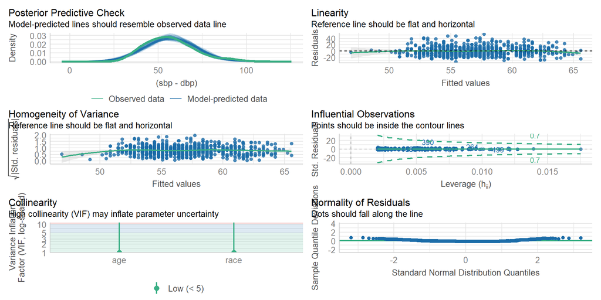

## `fit2` on each imputed data frame

3 estimates (coefficients) times 20 imputed data sets = 60 rows.

```r
m2_mods <- with(hbp_mice20, lm(pp ~ race + age))

summary(m2_mods)
```

```
# A tibble: 60 × 6
   term        estimate std.error statistic  p.value  nobs
   <chr>          <dbl>     <dbl>     <dbl>    <dbl> <int>
 1 (Intercept)   35.8      3.66        9.77 3.35e-21   700
 2 raceNHWhite   -1.91     1.15       -1.66 9.74e- 2   700
 3 age            0.331    0.0555      5.97 3.71e- 9   700
 4 (Intercept)   36.3      3.68        9.87 1.39e-21   700
 5 raceNHWhite   -1.77     1.18       -1.51 1.32e- 1   700
 6 age            0.323    0.0555      5.82 9.05e- 9   700
 7 (Intercept)   36.0      3.66        9.84 1.76e-21   700
 8 raceNHWhite   -1.84     1.15       -1.60 1.09e- 1   700
 9 age            0.327    0.0554      5.91 5.29e- 9   700
10 (Intercept)   36.0      3.66        9.82 2.01e-21   700
# ℹ 50 more rows
```

## Pool across the 20 imputations

```r
m2_pool <- pool(m2_mods)

n_obs(m2_pool)
```

```
 [1] 700 700 700 700 700 700 700 700 700 700 700 700 700 700 700 700 700 700 700
[20] 700
```

```r
model_parameters(m2_pool)
```

```
# Fixed Effects

Parameter      | Coefficient |   SE |         95% CI |     t |     df |      p
------------------------------------------------------------------------------
(Intercept)    |       36.04 | 3.67 | [28.84, 43.24] |  9.83 | 693.73 | < .001
race [NHWhite] |       -2.06 | 1.20 | [-4.42,  0.30] | -1.71 | 570.26 | 0.088
age            |        0.33 | 0.06 | [ 0.22,  0.44] |  5.92 | 693.81 | < .001
```

## Compare to our original `fit2`

```r
n_obs(fit2)
```

```
[1] 587
```

```r
model_parameters(fit2)
```

```
Parameter      | Coefficient |   SE |         95% CI | t(584) |      p
----------------------------------------------------------------------
(Intercept)    |       36.32 | 4.10 | [28.28, 44.37] |   8.87 | < .001
race [NHWhite] |       -2.04 | 1.29 | [-4.56,  0.49] |  -1.59 | 0.113
age            |        0.32 | 0.06 | [ 0.20,  0.45] |   5.16 | < .001
```

## Estimate $R^2$ and Adjusted $R^2$

```r
pool.r.squared(m2_mods)
```

```
           est     lo 95      hi 95         fmi
R^2 0.05052803 0.0233874 0.08659785 0.008321154
```

```r
pool.r.squared(m2_mods, adjusted = TRUE)
```

```
               est      lo 95      hi 95         fmi
adj R^2 0.04780299 0.02148981 0.08316104 0.008788525
```

```r
model_performance(fit2) # original model with NAs
```

```
# Indices of model performance

AIC      |     AICc |      BIC |    R2 | R2 (adj.) |   RMSE |  Sigma
--------------------------------------------------------------------
4759.475 | 4759.543 | 4776.975 | 0.046 |     0.043 | 13.850 | 13.886
```

Much, much more to come. See [Chapter 17 of our Course Book](https://thomaselove.github.io/431-book/17_adjtrans.html) for more discussion and an additional example.

# Breakout Activity 3

## R Packages

```r
library(janitor)
library(googlesheets4)
library(naniar)
library(xfun)
library(easystats)
library(tidyverse)

theme_set(theme_light())

source("c16/data/Love-431.R")
```

## Ingest the `movies_2024-10-15` data

```r
gs4_deauth()

url <- "https://docs.google.com/spreadsheets/d/16fm1693sFjau9sIM-ORamxLL3ZMrBeRSxXqWpP8IBDs/edit?gid=0#gid=0"

mov_raw <- read_sheet(url, na = c("", "NA"))

mov_clean <- mov_raw |>
  janitor::clean_names() |>
  mutate(across(where(is.character), as_factor)) |>
  mutate(across(c(mov_id, movie, director, star_1, star_2, star_3, origin,
                  fc_link, rt_link, imdb_cats, synopsis, imdb_id, imdb_link),
                as.character))
```

# Tukey (from Ajay)

## Data Clean for Tukey (from Ajay)

| Outcome | Binary | Covariate | Multi-Cat |
| --- | --- | --- | --- |
| potentially triggering events | primary language English | length | streaming services |

```r
mov_t1 <- mov_clean |>
  select(mov_id, movie, triggers, lang_1, length, stream_n) |>
  mutate(lang_english = ifelse(lang_1 == "English", 1, 0),
         length_s = scale(length, center = TRUE, scale = TRUE),
         stream_n = as_factor(stream_n),
         stream_f = fct_collapse(stream_n,
                                 "0-2" = c(0, 1, 2), "4-5" = c(4, 5)),
         stream_f = fct_relevel(stream_f, "0-2", "3", "4-5"))
```

## Missing Status

Tukey (from Ajay)

```r
miss_case_table(mov_t1)
```

```
# A tibble: 2 × 3
  n_miss_in_case n_cases pct_cases
           <int>   <int>     <dbl>
1              0     225     98.7
2              1       3      1.32
```

```r
miss_var_summary(mov_t1) |> filter(n_miss > 0)
```

```
# A tibble: 1 × 3
  variable n_miss pct_miss
  <chr>     <int>    <num>
1 triggers      3     1.32
```

## Outcome and Covariate

Tukey (from Ajay)

```r
a1 <- mov_t1 |> reframe(lovedist(triggers)) |> mutate(var = "triggers")
a2 <- mov_t1 |> reframe(lovedist(length)) |> mutate(var = "length")
a3 <- mov_t1 |> reframe(lovedist(length_s)) |> mutate(var = "length_s")

rbind(a1, a2, a3) |> relocate(var) |>
  kable(digits = 1) |> kable_styling(font_size = 20)
```

| var | n | miss | mean | sd | med | mad | min | q25 | q75 | max |
| --- | --- | --- | --- | --- | --- | --- | --- | --- | --- | --- |
| triggers | 228 | 3 | 26.0 | 18.9 | 24.0 | 22.2 | 0.0 | 10.0 | 41.0 | 77.0 |
| length | 228 | 0 | 123.2 | 25.6 | 117.5 | 24.5 | 70.0 | 103.0 | 138.0 | 207.0 |
| length_s | 228 | 0 | 0.0 | 1.0 | -0.2 | 1.0 | -2.1 | -0.8 | 0.6 | 3.3 |

## Correlations

Tukey (from Ajay)

```r
correlation(mov_t1 |> select(triggers, length_s, length))
```

```
# Correlation Matrix (pearson-method)

Parameter1 | Parameter2 |    r |       95% CI |    t |  df |         p
----------------------------------------------------------------------
triggers   |   length_s | 0.15 | [0.02, 0.28] | 2.33 | 223 | 0.042*
triggers   |     length | 0.15 | [0.02, 0.28] | 2.33 | 223 | 0.042*
length_s   |     length | 1.00 | [1.00, 1.00] |  Inf | 226 | < .001***

p-value adjustment method: Holm (1979)
Observations: 225-228
```

## Binary and Multi-Category Variables

Tukey (from Ajay)

```r
mov_t1 |> tabyl(lang_english, stream_n) |>
  adorn_totals(where = c("row", "col"))
```

```
 lang_english 0 1  2  3   4  5 Total
            0 4 3  5 12   4  0    28
            1 5 4  5 68 106 12   200
        Total 9 7 10 80 110 12   228
```

```r
mov_t1 |> tabyl(lang_english, stream_f) |>
  adorn_totals(where = c("row", "col"))
```

```
 lang_english 0-2  3 4-5 Total
            0  12 12   4    28
            1  14 68 118   200
        Total  26 80 122   228
```

## Fit 1

Tukey (from Ajay)

```r
fit1_t1 <- lm(triggers ~ lang_english, data = mov_t1)

n_obs(fit1_t1)
```

```
[1] 225
```

```r
model_parameters(fit1_t1)
```

```
Parameter    | Coefficient |   SE |        95% CI | t(223) |      p
-------------------------------------------------------------------
(Intercept)  |       12.96 | 3.59 | [5.88, 20.04] |   3.61 | < .001
lang english |       14.69 | 3.82 | [7.16, 22.22] |   3.85 | < .001
```

```r
model_performance(fit1_t1)
```

```
# Indices of model performance

AIC      |     AICc |      BIC |    R2 | R2 (adj.) |   RMSE |  Sigma
--------------------------------------------------------------------
1951.153 | 1951.262 | 1961.402 | 0.062 |     0.058 | 18.240 | 18.322
```

## Fit 2

Tukey (from Ajay)

```r
fit2_t1 <- lm(triggers ~ lang_english + length_s, data = mov_t1)

n_obs(fit2_t1)
```

```
[1] 225
```

```r
model_parameters(fit2_t1)
```

```
Parameter    | Coefficient |   SE |        95% CI | t(222) |      p
-------------------------------------------------------------------
(Intercept)  |       11.25 | 3.57 | [4.22, 18.28] |   3.15 | 0.002
lang english |       16.65 | 3.80 | [9.16, 24.14] |   4.38 | < .001
length s     |        3.77 | 1.21 | [1.38,  6.16] |   3.11 | 0.002
```

```r
model_performance(fit2_t1)
```

```
# Indices of model performance

AIC      |     AICc |      BIC |    R2 | R2 (adj.) |   RMSE |  Sigma
--------------------------------------------------------------------
1943.547 | 1943.728 | 1957.211 | 0.101 |     0.093 | 17.855 | 17.975
```

## Fit 3

Tukey (from Ajay)

```r
fit3_t1 <- lm(triggers ~ stream_f + length_s, data = mov_t1)

n_obs(fit3_t1)
```

```
[1] 225
```

```r
model_parameters(fit3_t1)
```

```
Parameter      | Coefficient |   SE |         95% CI | t(221) |      p
----------------------------------------------------------------------
(Intercept)    |       18.42 | 3.67 | [11.19, 25.65] |   5.02 | < .001
stream f [3]   |        4.58 | 4.21 | [-3.72, 12.88] |   1.09 | 0.278
stream f [4-5] |       11.06 | 4.03 | [ 3.13, 19.00] |   2.75 | 0.007
length s       |        3.00 | 1.22 | [ 0.59,  5.40] |   2.45 | 0.015
```

```r
model_performance(fit3_t1)
```

```
# Indices of model performance

AIC      |     AICc |      BIC |    R2 | R2 (adj.) |   RMSE |  Sigma
--------------------------------------------------------------------
1953.522 | 1953.796 | 1970.602 | 0.069 |     0.056 | 18.174 | 18.338
```

# Hard R Cafe

## Data Clean for Hard R Cafe

| Outcome | Binary | Covariate | Multi-Cat |
| --- | --- | --- | --- |
| potentially triggering events | country of origin includes US | year (or age) | oscars won |

```r
mov_hrc <- mov_clean |>
  select(mov_id, movie, triggers, origin, year, oscars) |>
  mutate(origin_us = as.numeric(str_detect(origin, pattern = "USA")),
         age = 2024 - year,
         age_s = scale(age, center = TRUE, scale = TRUE),
         oscars = as_factor(oscars),
         oscar_f = fct_lump(oscars, n = 2, other_level = "2+"))
```

## Missing Status

Hard R Cafe

```r
miss_case_table(mov_hrc)
```

```
# A tibble: 2 × 3
  n_miss_in_case n_cases pct_cases
           <int>   <int>     <dbl>
1              0     225     98.7
2              1       3      1.32
```

```r
miss_var_summary(mov_hrc) |> filter(n_miss > 0)
```

```
# A tibble: 1 × 3
  variable n_miss pct_miss
  <chr>     <int>    <num>
1 triggers      3     1.32
```

## Outcome and Covariate

Hard R Cafe

```r
a1 <- mov_hrc |> reframe(lovedist(triggers)) |> mutate(var = "triggers")
a2 <- mov_hrc |> reframe(lovedist(age)) |> mutate(var = "age")
a3 <- mov_hrc |> reframe(lovedist(age_s)) |> mutate(var = "age_s")

rbind(a1, a2, a3) |> relocate(var) |>
  kable(digits = 1) |> kable_styling(font_size = 20)
```

| var | n | miss | mean | sd | med | mad | min | q25 | q75 | max |
| --- | --- | --- | --- | --- | --- | --- | --- | --- | --- | --- |
| triggers | 228 | 3 | 26.0 | 18.9 | 24.0 | 22.2 | 0.0 | 10.0 | 41.0 | 77.0 |
| age | 228 | 0 | 21.1 | 14.3 | 18.0 | 11.9 | 0.0 | 11.0 | 28.0 | 82.0 |
| age_s | 228 | 0 | 0.0 | 1.0 | -0.2 | 0.8 | -1.5 | -0.7 | 0.5 | 4.3 |

## Correlations

Hard R Cafe

```r
correlation(mov_hrc |> select(triggers, age_s, age))
```

```
# Correlation Matrix (pearson-method)

Parameter1 | Parameter2 |     r |        95% CI |     t |  df |         p
-------------------------------------------------------------------------
triggers   |      age_s | -0.06 | [-0.19, 0.08] | -0.83 | 223 | 0.811
triggers   |        age | -0.06 | [-0.19, 0.08] | -0.83 | 223 | 0.811
age_s      |        age |  1.00 | [ 1.00, 1.00] |   Inf | 226 | < .001***

p-value adjustment method: Holm (1979)
Observations: 225-228
```

## Binary and Multi-Category Variables

Hard R Cafe

```r
mov_hrc |> tabyl(origin_us, oscars) |>
  adorn_totals(where = c("row", "col"))
```

```
 origin_us   0  1  2  3 4 5 6 7 8 11 Total
         0  29  1  1  2 0 0 0 0 0  0    33
         1 123 29 13 11 8 3 2 2 2  2   195
     Total 152 30 14 13 8 3 2 2 2  2   228
```

```r
mov_hrc |> tabyl(origin_us, oscar_f) |>
  adorn_totals(where = c("row", "col"))
```

```
 origin_us   0  1 2+ Total
         0  29  1  3    33
         1 123 29 43   195
     Total 152 30 46   228
```

## Fit 1

Hard R Cafe

```r
fit1_hrc <- lm(triggers ~ origin_us, data = mov_hrc)

n_obs(fit1_hrc)
```

```
[1] 225
```

```r
model_parameters(fit1_hrc)
```

```
Parameter   | Coefficient |   SE |        95% CI | t(223) |      p
------------------------------------------------------------------
(Intercept) |       14.10 | 3.29 | [7.62, 20.58] |   4.29 | < .001
origin us   |       13.75 | 3.54 | [6.77, 20.73] |   3.88 | < .001
```

```r
model_performance(fit1_t1)
```

```
# Indices of model performance

AIC      |     AICc |      BIC |    R2 | R2 (adj.) |   RMSE |  Sigma
--------------------------------------------------------------------
1951.153 | 1951.262 | 1961.402 | 0.062 |     0.058 | 18.240 | 18.322
```

## Fit 2

Hard R Cafe

```r
fit2_hrc <- lm(triggers ~ origin_us + age_s, data = mov_hrc)

n_obs(fit2_hrc)
```

```
[1] 225
```

```r
model_parameters(fit2_hrc)
```

```
Parameter   | Coefficient |   SE |         95% CI | t(222) |      p
-------------------------------------------------------------------
(Intercept) |       14.20 | 3.30 | [ 7.70, 20.69] |   4.31 | < .001
origin us   |       13.64 | 3.55 | [ 6.64, 20.63] |   3.84 | < .001
age s       |       -0.84 | 1.25 | [-3.30,  1.63] |  -0.67 | 0.504
```

```r
model_performance(fit2_hrc)
```

```
# Indices of model performance

AIC      |     AICc |      BIC |    R2 | R2 (adj.) |   RMSE |  Sigma
--------------------------------------------------------------------
1952.421 | 1952.603 | 1966.085 | 0.065 |     0.057 | 18.210 | 18.333
```

## Fit 3

Hard R Cafe

```r
fit3_hrc <- lm(triggers ~ oscar_f + age_s, data = mov_hrc)

n_obs(fit3_hrc)
```

```
[1] 225
```

```r
model_parameters(fit3_hrc)
```

```
Parameter    | Coefficient |   SE |         95% CI | t(221) |      p
--------------------------------------------------------------------
(Intercept)  |       22.42 | 1.50 | [19.47, 25.37] |  14.98 | < .001
oscar f [1]  |       10.50 | 3.67 | [ 3.28, 17.72] |   2.86 | 0.005
oscar f [2+] |       10.66 | 3.12 | [ 4.50, 16.81] |   3.41 | < .001
age s        |       -1.56 | 1.25 | [-4.02,  0.91] |  -1.24 | 0.215
```

```r
model_performance(fit3_hrc)
```

```
# Indices of model performance

AIC      |     AICc |      BIC |    R2 | R2 (adj.) |   RMSE |  Sigma
--------------------------------------------------------------------
1952.596 | 1952.870 | 1969.677 | 0.073 |     0.060 | 18.137 | 18.300
```

# Tukey (from Atticus)

## Data Clean: Tukey (from Atticus)

| Outcome | Binary | Covariate | Multi-Cat |
| --- | --- | --- | --- |
| potentially triggering events | star 1 gender | length | oscars won |

```r
mov_t2 <- mov_clean |>
  select(mov_id, movie, triggers, gen_1, length, oscars) |>
  mutate(length_s = scale(length, center = TRUE, scale = TRUE),
         oscars = as_factor(oscars),
         oscar_f = fct_lump(oscars, n = 2, other_level = "2+"))
```

## Missing Status

Tukey (from Atticus)

```r
miss_case_table(mov_t2)
```

```
# A tibble: 2 × 3
  n_miss_in_case n_cases pct_cases
           <int>   <int>     <dbl>
1              0     225     98.7
2              1       3      1.32
```

```r
miss_var_summary(mov_t2) |> filter(n_miss > 0)
```

```
# A tibble: 1 × 3
  variable n_miss pct_miss
  <chr>     <int>    <num>
1 triggers      3     1.32
```

## Outcome and Covariate

Tukey (from Atticus)

```r
a1 <- mov_t2 |> reframe(lovedist(triggers)) |> mutate(var = "triggers")
a2 <- mov_t2 |> reframe(lovedist(length)) |> mutate(var = "length")
a3 <- mov_t2 |> reframe(lovedist(length_s)) |> mutate(var = "length_s")

rbind(a1, a2, a3) |> relocate(var) |>
  kable(digits = 1) |> kable_styling(font_size = 20)
```

| var | n | miss | mean | sd | med | mad | min | q25 | q75 | max |
| --- | --- | --- | --- | --- | --- | --- | --- | --- | --- | --- |
| triggers | 228 | 3 | 26.0 | 18.9 | 24.0 | 22.2 | 0.0 | 10.0 | 41.0 | 77.0 |
| length | 228 | 0 | 123.2 | 25.6 | 117.5 | 24.5 | 70.0 | 103.0 | 138.0 | 207.0 |
| length_s | 228 | 0 | 0.0 | 1.0 | -0.2 | 1.0 | -2.1 | -0.8 | 0.6 | 3.3 |

## Correlations

Tukey (from Atticus)

```r
correlation(mov_t2 |> select(triggers, length_s, length))
```

```
# Correlation Matrix (pearson-method)

Parameter1 | Parameter2 |    r |       95% CI |    t |  df |         p
----------------------------------------------------------------------
triggers   |   length_s | 0.15 | [0.02, 0.28] | 2.33 | 223 | 0.042*
triggers   |     length | 0.15 | [0.02, 0.28] | 2.33 | 223 | 0.042*
length_s   |     length | 1.00 | [1.00, 1.00] |  Inf | 226 | < .001***

p-value adjustment method: Holm (1979)
Observations: 225-228
```

## Binary and Multi-Category Variables

Tukey (from Atticus)

```r
mov_t2 |> tabyl(gen_1, oscars) |>
  adorn_totals(where = c("row", "col"))
```

```
 gen_1   0  1  2  3 4 5 6 7 8 11 Total
     M 114 25 13 11 8 2 2 0 1  2   178
     F  38  5  1  2 0 1 0 2 1  0    50
 Total 152 30 14 13 8 3 2 2 2  2   228
```

```r
mov_t2 |> tabyl(gen_1, oscar_f) |>
  adorn_totals(where = c("row", "col"))
```

```
 gen_1   0  1 2+ Total
     M 114 25 39   178
     F  38  5  7    50
 Total 152 30 46   228
```

## Fit 1

Tukey (from Atticus)

```r
fit1_t2 <- lm(triggers ~ gen_1, data = mov_t2)

n_obs(fit1_t2)
```

```
[1] 225
```

```r
model_parameters(fit1_t2)
```

```
Parameter   | Coefficient |   SE |         95% CI | t(223) |      p
-------------------------------------------------------------------
(Intercept) |       26.33 | 1.43 | [23.52, 29.15] |  18.42 | < .001
gen 1 [F]   |       -1.69 | 3.03 | [-7.67,  4.28] |  -0.56 | 0.577
```

```r
model_performance(fit1_t2)
```

```
# Indices of model performance

AIC      |     AICc |      BIC |    R2 | R2 (adj.) |   RMSE |  Sigma
--------------------------------------------------------------------
1965.284 | 1965.393 | 1975.533 | 0.001 |    -0.003 | 18.822 | 18.906
```

## Fit 2

Tukey (from Atticus)

```r
fit2_t2 <- lm(triggers ~ gen_1 + length_s, data = mov_t2)

n_obs(fit2_t2)
```

```
[1] 225
```

```r
model_parameters(fit2_t2)
```

```
Parameter   | Coefficient |   SE |         95% CI | t(222) |      p
-------------------------------------------------------------------
(Intercept) |       26.12 | 1.42 | [23.32, 28.91] |  18.40 | < .001
gen 1 [F]   |       -0.63 | 3.04 | [-6.63,  5.36] |  -0.21 | 0.835
length s    |        2.85 | 1.26 | [ 0.37,  5.34] |   2.26 | 0.025
```

```r
model_performance(fit2_t2)
```

```
# Indices of model performance

AIC      |     AICc |      BIC |    R2 | R2 (adj.) |   RMSE |  Sigma
--------------------------------------------------------------------
1962.161 | 1962.343 | 1975.826 | 0.024 |     0.015 | 18.609 | 18.734
```

## Fit 3

Tukey (from Atticus)

```r
fit3_t2 <- lm(triggers ~ oscar_f + length_s, data = mov_t2)

n_obs(fit3_t2)
```

```
[1] 225
```

```r
model_parameters(fit3_t2)
```

```
Parameter    | Coefficient |   SE |         95% CI | t(221) |      p
--------------------------------------------------------------------
(Intercept)  |       22.84 | 1.50 | [19.87, 25.80] |  15.18 | < .001
oscar f [1]  |        9.74 | 3.67 | [ 2.51, 16.96] |   2.66 | 0.008
oscar f [2+] |        9.17 | 3.19 | [ 2.89, 15.45] |   2.88 | 0.004
length s     |        1.97 | 1.25 | [-0.49,  4.43] |   1.58 | 0.116
```

```r
model_performance(fit3_t2)
```

```
# Indices of model performance

AIC      |     AICc |      BIC |    R2 | R2 (adj.) |   RMSE |  Sigma
--------------------------------------------------------------------
1951.653 | 1951.927 | 1968.733 | 0.077 |     0.064 | 18.099 | 18.262
```

# Halloween Time Stats

## Data Clean for Halloween Time Stats

| Outcome | Binary | Covariate | Multi-Cat |
| --- | --- | --- | --- |
| budget | origin in US | year (or age) | Bechdel-Wallace |

```r
mov_hts <- mov_clean |>
  select(mov_id, movie, budget, origin, year, bw_rating) |>
  mutate(budgetM = budget/1000000,
         origin_us = as.numeric(str_detect(origin, pattern = "USA")),
         age = 2024 - year,
         age_s = scale(age, center = TRUE, scale = TRUE))
```

## Missing Status

Halloween Time Stats

```r
miss_case_table(mov_hts)
```

```
# A tibble: 4 × 3
  n_miss_in_case n_cases pct_cases
           <int>   <int>     <dbl>
1              0     203     89.0
2              1       3      1.32
3              2      15      6.58
4              3       7      3.07
```

```r
miss_var_summary(mov_hts) |> filter(n_miss > 0)
```

```
# A tibble: 3 × 3
  variable  n_miss pct_miss
  <chr>      <int>    <num>
1 budget        22     9.65
2 budgetM       22     9.65
3 bw_rating     10     4.39
```

## Outcome and Covariate

Halloween Time Stats

```r
a1 <- mov_hts |> reframe(lovedist(budgetM)) |> mutate(var = "budgetM")
a2 <- mov_hts |> reframe(lovedist(age)) |> mutate(var = "age")
a3 <- mov_hts |> reframe(lovedist(age_s)) |> mutate(var = "age_s")

rbind(a1, a2, a3) |> relocate(var) |>
  kable(digits = 1) |> kable_styling(font_size = 20)
```

| var | n | miss | mean | sd | med | mad | min | q25 | q75 | max |
| --- | --- | --- | --- | --- | --- | --- | --- | --- | --- | --- |
| budgetM | 228 | 22 | 59.1 | 66.5 | 30.0 | 35.6 | 0.2 | 13.0 | 90.0 | 356.0 |
| age | 228 | 0 | 21.1 | 14.3 | 18.0 | 11.9 | 0.0 | 11.0 | 28.0 | 82.0 |
| age_s | 228 | 0 | 0.0 | 1.0 | -0.2 | 0.8 | -1.5 | -0.7 | 0.5 | 4.3 |

## Correlations

Halloween Time Stats

```r
correlation(mov_hts |> select(budgetM, age_s, age))
```

```
# Correlation Matrix (pearson-method)

Parameter1 | Parameter2 |     r |         95% CI |     t |  df |         p
--------------------------------------------------------------------------
budgetM    |      age_s | -0.38 | [-0.49, -0.26] | -5.91 | 204 | < .001***
budgetM    |        age | -0.38 | [-0.49, -0.26] | -5.91 | 204 | < .001***
age_s      |        age |  1.00 | [ 1.00,  1.00] |   Inf | 226 | < .001***

p-value adjustment method: Holm (1979)
Observations: 206-228
```

## Binary and Multi-Category Variables

Halloween Time Stats

```r
mov_hts |> tabyl(origin_us, bw_rating) |>
  adorn_totals(where = c("row", "col"))
```

```
 origin_us  0  1  2   3 NA_ Total
         0  4  6  1  15   7    33
         1 14 55 14 109   3   195
     Total 18 61 15 124  10   228
```

## Fit 1

Halloween Time Stats

```r
fit1_hts <- lm(budgetM ~ origin_us, data = mov_hts)

n_obs(fit1_hts)
```

```
[1] 206
```

```r
model_parameters(fit1_hts)
```

```
Parameter   | Coefficient |    SE |          95% CI | t(204) |      p
---------------------------------------------------------------------
(Intercept) |       11.00 | 14.49 | [-17.56, 39.56] |   0.76 | 0.449
origin us   |       53.28 | 15.25 | [ 23.22, 83.34] |   3.49 | < .001
```

```r
model_performance(fit1_hts)
```

```
# Indices of model performance

AIC      |     AICc |      BIC |    R2 | R2 (adj.) |   RMSE |  Sigma
--------------------------------------------------------------------
2307.089 | 2307.208 | 2317.073 | 0.056 |     0.052 | 64.472 | 64.787
```

## Fit 2

Halloween Time Stats

```r
fit2_hts <- lm(budgetM ~ origin_us + age_s, data = mov_hts)

n_obs(fit2_hts)
```

```
[1] 206
```

```r
model_parameters(fit2_hts)
```

```
Parameter   | Coefficient |    SE |           95% CI | t(203) |      p
----------------------------------------------------------------------
(Intercept) |       19.00 | 13.57 | [ -7.75,  45.74] |   1.40 | 0.163
origin us   |       44.72 | 14.28 | [ 16.56,  72.87] |   3.13 | 0.002
age s       |      -24.75 |  4.36 | [-33.36, -16.14] |  -5.67 | < .001
```

```r
model_performance(fit2_hts)
```

```
# Indices of model performance

AIC      |     AICc |      BIC |    R2 | R2 (adj.) |   RMSE |  Sigma
--------------------------------------------------------------------
2278.799 | 2278.998 | 2292.110 | 0.185 |     0.177 | 59.902 | 60.343
```

## Fit 3

Halloween Time Stats

```r
fit3_hts <- lm(budgetM ~ bw_rating + age_s, data = mov_hts)

n_obs(fit3_hts)
```

```
[1] 203
```

```r
model_parameters(fit3_hts)
```

```
Parameter   | Coefficient |   SE |           95% CI | t(200) |      p
---------------------------------------------------------------------
(Intercept) |       55.33 | 9.63 | [ 36.33,  74.32] |   5.74 | < .001
bw rating   |        2.25 | 4.08 | [ -5.80,  10.31] |   0.55 | 0.582
age s       |      -25.65 | 4.53 | [-34.59, -16.72] |  -5.66 | < .001
```

```r
model_performance(fit3_hts)
```

```
# Indices of model performance

AIC      |     AICc |      BIC |    R2 | R2 (adj.) |   RMSE |  Sigma
--------------------------------------------------------------------
2256.107 | 2256.309 | 2269.360 | 0.147 |     0.138 | 61.453 | 61.912
```

# Data Cleaning and Missing Status only

## Data Clean for Something Unique Tokyo Drift

| Outcome | Binary | Covariate | Multi-Cat |
| --- | --- | --- | --- |
| budget | origin in US | length | oscars won |

```r
mov_sutd <- mov_clean |>
  select(mov_id, movie, budget, origin, length, oscars) |>
  mutate(budgetM = budget/1000000,
         origin_us = as.numeric(str_detect(origin, pattern = "USA")),
         length_s = scale(length, center = TRUE, scale = TRUE),
         oscars = as_factor(oscars),
         oscar_f = fct_lump(oscars, n = 2, other_level = "2+"))
```

## Missing Status

Something Unique Tokyo Drift

```r
miss_case_table(mov_sutd)
```

```
# A tibble: 2 × 3
  n_miss_in_case n_cases pct_cases
           <int>   <int>     <dbl>
1              0     206     90.4
2              2      22      9.65
```

```r
miss_var_summary(mov_sutd) |> filter(n_miss > 0)
```

```
# A tibble: 2 × 3
  variable n_miss pct_miss
  <chr>     <int>    <num>
1 budget       22     9.65
2 budgetM      22     9.65
```

## Data Clean for PB&J

| Outcome | Binary | Covariate | Multi-Cat |
| --- | --- | --- | --- |
| gross revenue | star 1 gender | budget | oscars won |

```r
mov_pbj <- mov_clean |>
  select(mov_id, movie, gross_world, gen_1, budget, oscars) |>
  mutate(grossM = gross_world/1000000,
         budget_s = scale(budget, center = TRUE, scale = TRUE),
         oscars = as_factor(oscars),
         oscar_f = fct_lump(oscars, n = 2, other_level = "2+"))
```

## Missing Status

PB&J

```r
miss_case_table(mov_pbj)
```

```
# A tibble: 3 × 3
  n_miss_in_case n_cases pct_cases
           <int>   <int>     <dbl>
1              0     204     89.5
2              2      18      7.89
3              4       6      2.63
```

```r
miss_var_summary(mov_pbj) |> filter(n_miss > 0)
```

```
# A tibble: 4 × 3
  variable      n_miss pct_miss
  <chr>          <int>    <num>
1 "budget"          22     9.65
2 ""                22     9.65
3 "gross_world"      8     3.51
4 "grossM"           8     3.51
```

## Data Clean for And Then There Were Three

| Outcome | Binary | Covariate | Multi-Cat |
| --- | --- | --- | --- |
| gross revenue | drama | sex-nudity rating | ebert rating |

```r
mov_attwt <- mov_clean |>
  select(mov_id, movie, gross_world, drama, kim_sn, ebert) |>
  mutate(grossM = gross_world/1000000,
         ebert = as_factor(ebert),
         ebert_f = fct_lump(ebert, n = 4, other_level = "1-2"),
         ebert_f = fct_relevel(ebert_f, "1-2"))
```

## Missing Status

And Then There Were Three

```r
miss_case_table(mov_attwt)
```

```
# A tibble: 5 × 3
  n_miss_in_case n_cases pct_cases
           <int>   <int>     <dbl>
1              0     146     64.0
2              1      50     21.9
3              2      11      4.82
4              3      16      7.02
5              5       5      2.19
```

```r
miss_var_summary(mov_attwt) |> filter(n_miss > 0)
```

```
# A tibble: 5 × 3
  variable    n_miss pct_miss
  <chr>        <int>    <num>
1 kim_sn          71    31.1
2 ebert           29    12.7
3 ebert_f         29    12.7
4 gross_world      8     3.51
5 grossM           8     3.51
```

## Data Clean for Vintage Macbooks

| Outcome | Binary | Covariate | Multi-Cat |
| --- | --- | --- | --- |
| awards won | has Dr. Love seen | length | Bechdel-Wallace |

```r
mov_vm <- mov_clean |>
  select(mov_id, movie, awards, dr_love, length, bw_rating) |>
  mutate(length_s = scale(length, center = TRUE, scale = TRUE))
```

## Missing Status

Vintage Macbooks

```r
miss_case_table(mov_vm)
```

```
# A tibble: 2 × 3
  n_miss_in_case n_cases pct_cases
           <int>   <int>     <dbl>
1              0     218     95.6
2              1      10      4.39
```

```r
miss_var_summary(mov_vm) |> filter(n_miss > 0)
```

```
# A tibble: 1 × 3
  variable  n_miss pct_miss
  <chr>      <int>    <num>
1 bw_rating     10     4.39
```

## Data Clean for Ghostbusters

| Outcome | Binary | Covariate | Multi-Cat |
| --- | --- | --- | --- |
| awards won | star 1 gender | year (or age) | Bechdel-Wallace |

```r
mov_gb <- mov_clean |>
  select(mov_id, movie, awards, gen_1, year, bw_rating) |>
  mutate(age = 2024 - year,
         age_s = scale(age, center = TRUE, scale = TRUE))
```

## Missing Status

Ghostbusters

```r
miss_case_table(mov_gb)
```

```
# A tibble: 2 × 3
  n_miss_in_case n_cases pct_cases
           <int>   <int>     <dbl>
1              0     218     95.6
2              1      10      4.39
```

```r
miss_var_summary(mov_gb) |> filter(n_miss > 0)
```

```
# A tibble: 1 × 3
  variable  n_miss pct_miss
  <chr>      <int>    <num>
1 bw_rating     10     4.39
```

431 Class 16 | 2024-10-17 | https://thomaselove.github.io/431-2024/